# Sistemas de Información Geográfica con R

Autocorrelación Espacial

Edimer David Jaramillo

- Notas tomadas del curso [“Sistemas de Información Geográfica en R (SIG en R)” con Derek Corcoran.](https://www.youtube.com/watch?v=IYURqbzKVkQ&ab_channel=DerekCorcoran)

[video not shown]

# Bibliotecas

```r
library(tidyverse)
library(sp)
library(sf)
library(gstat)
library(rgdal)
library(rworldxtra)
library(raster)
```

# Ley de Tobler

> “Todas las cosas están relacionadas entre sí, pero las cosas más próximas en el espacio tienen una relación mayor que las distantes.” Waldo Tobler

# Bibliotecas

```r
library(gstat)
library(raster)
library(rgdal)
library(rworldxtra)
library(sp)
library(sf)
library(tidyverse)
```

# Datos *meuse*

- Datos de ejemplo contenidos en la biblioteca sp.
- El crs asignado es determinado por las unidades en las cuales está dada la longitud y latitud.
- En este caso se transforman los datos a *sf* y a *SpatialPoints*.

```r
# Data originakl
data("meuse")

# Data sf
meuse_sf <- meuse %>% st_as_sf(coords = c(1, 2), crs = "+init=epsg:28992")

# Data SpatialPoints
coordinates(meuse) <- ~ x + y

# Clase de objetos
class(meuse)
```

```
[1] "SpatialPointsDataFrame"
attr(,"package")
[1] "sp"
```

```r
class(meuse_sf)
```

```
[1] "sf"         "data.frame"
```

- **Concentración de Zinc:**

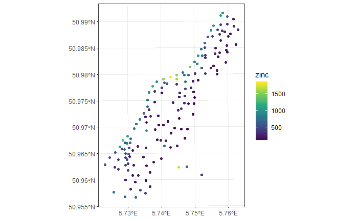

```r
meuse_sf %>%
  ggplot() +
  geom_sf(aes(color = zinc)) +
  theme_bw() +
  scale_color_viridis_c()
```

# Ubicación meuse

```r
library(leaflet)
leaflet(as_Spatial(st_transform(meuse_sf, crs = 4326))) %>% addTiles() %>% addCircles()
```

[interactive chart not shown]

# Variograma

- [El Variograma](https://es.wikipedia.org/wiki/Variograma#:~:text=El%20variograma%20o%20semivariograma%20es,otro%20punto%20a%20diferentes%20distancias.) es una medida de variación entre valores a distintas distancias.
- A mayor distancia se espera mayor variación.
- El logaritmo se adiciona para garantizar la obtención de valores positivos.
- Es posible modelar la variación en función de diferentes fuentes o factores, dando lugar con ello a diferentes variogramas.

## Modelo Nulo

```r
#Modelo nulo
variograma_nulo <- variogram(object = log(zinc) ~ 1, data = meuse)
variograma_nulo
```

| np | dist | gamma | dir.hor | dir.ver | id |
| --- | --- | --- | --- | --- | --- |
| 57 | 79.29244 | 0.1234479 | 0 | 0 | var1 |
| 299 | 163.97367 | 0.2162185 | 0 | 0 | var1 |
| 419 | 267.36483 | 0.3027859 | 0 | 0 | var1 |
| 457 | 372.73542 | 0.4121448 | 0 | 0 | var1 |
| 547 | 478.47670 | 0.4634128 | 0 | 0 | var1 |
| 533 | 585.34058 | 0.5646933 | 0 | 0 | var1 |
| 574 | 693.14526 | 0.5689683 | 0 | 0 | var1 |
| 564 | 796.18365 | 0.6186769 | 0 | 0 | var1 |
| 589 | 903.14650 | 0.6471479 | 0 | 0 | var1 |
| 543 | 1011.29177 | 0.6915705 | 0 | 0 | var1 |

[output cut: 5 more lines]

- **Resultados de tabla anterior:** la primera variable (np) proporciona información del número de puntos, es decir, que para la primera fila diremos que hay 57 puntos a una distancia (dist) de 79.29244 metros y la semi-varianza entre estos 57 puntos es 0.1234479 (gamma). El punto de mayor variación se da con 0.7033984 a una distancia de 1117.86 metros.

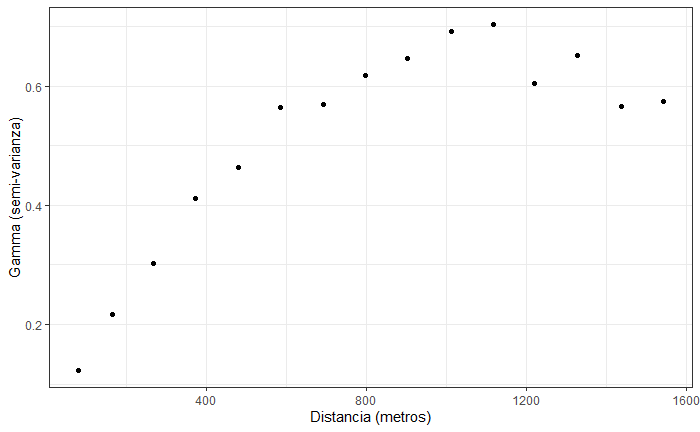

```r
variograma_nulo %>%
  ggplot(aes(x = dist, y = gamma)) +
  geom_point() +
  theme_bw() +
  labs(x = "Distancia (metros)", y = "Gamma (semi-varianza)")
```

## Comparando variogramas

```r
# Variogramas
var_nulo <- variogram(log(zinc) ~ 1, data = meuse) %>% mutate(Modelo = "Nulo")
var_spat <- variogram(log(zinc) ~ x + y, data = meuse) %>% mutate(Modelo = "Espacial")
var_dist <- variogram(log(zinc) ~ dist, data = meuse) %>% mutate(Modelo = "Distancia")
var_sqrt <- variogram(log(zinc) ~ sqrt(dist), data = meuse) %>% mutate(Modelo = "Raíz Distancia")

# Uniendo resultados
all_var <- list(var_nulo, var_spat, var_dist, var_sqrt) %>%
  reduce(bind_rows)
all_var
```

| np | dist | gamma | dir.hor | dir.ver | id | Modelo |
| --- | --- | --- | --- | --- | --- | --- |
| 57 | 79.29244 | 0.12344793 | 0 | 0 | var1 | Nulo |
| 299 | 163.97367 | 0.21621849 | 0 | 0 | var1 | Nulo |
| 419 | 267.36483 | 0.30278588 | 0 | 0 | var1 | Nulo |
| 457 | 372.73542 | 0.41214476 | 0 | 0 | var1 | Nulo |
| 547 | 478.47670 | 0.46341279 | 0 | 0 | var1 | Nulo |
| 533 | 585.34058 | 0.56469327 | 0 | 0 | var1 | Nulo |
| 574 | 693.14526 | 0.56896826 | 0 | 0 | var1 | Nulo |
| 564 | 796.18365 | 0.61867686 | 0 | 0 | var1 | Nulo |
| 589 | 903.14650 | 0.64714789 | 0 | 0 | var1 | Nulo |
| 543 | 1011.29177 | 0.69157049 | 0 | 0 | var1 | Nulo |

[output cut: 50 more lines]

- **Gráfico de variogramas:**

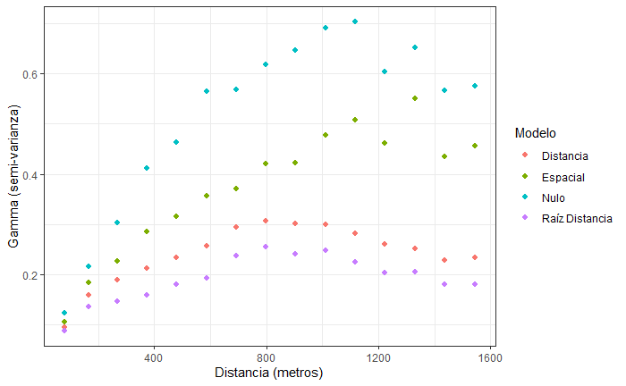

```r
all_var %>%
  ggplot(aes(x = dist, y = gamma, color = Modelo)) +
  geom_point(size = 1.7) +
  theme_bw() +
  labs(x = "Distancia (metros)", y = "Gamma (semi-varianza)")
```

# Ajuste de variograma

- psill: meseta parcial. Estabilización de la semivarianza.
- range: separación o distancia entre pares de puntos en la cual ya no hay dependencia espacial.
- nugget: semivarianza esperada a la separación o distancia de 0m
- Los valores de psill, range y nugget sirven como valores iniciales para el ajuste del modelo.

```r
ajuste_var <- fit.variogram(object = var_spat,
                            model = vgm(psill = 1, model = "Sph", range =  700,
                                        nugget =  1))
ajuste_var
```

|  | model | psill | range |
| --- | --- | --- | --- |
| 1 | Nug | 0.08234213 | 0.000 |
| 2 | Sph | 0.38866509 | 1098.571 |

- **Resultados:** el *range* proporcionado por el modelo indica la distancia esperada donde se estabiliza la semivarianza. La suma de *psill* (0.08234213 + 0.38866509) dará como resultado el valor donde se evidencia o espera la “meseta” total (estabilización de la semivarianza). *Nugget* brinda información acerca de la semivarianza esperada a una distancia de 0 metros (intercepto). A continuación se muestra el gráfico del modelo ajustado:

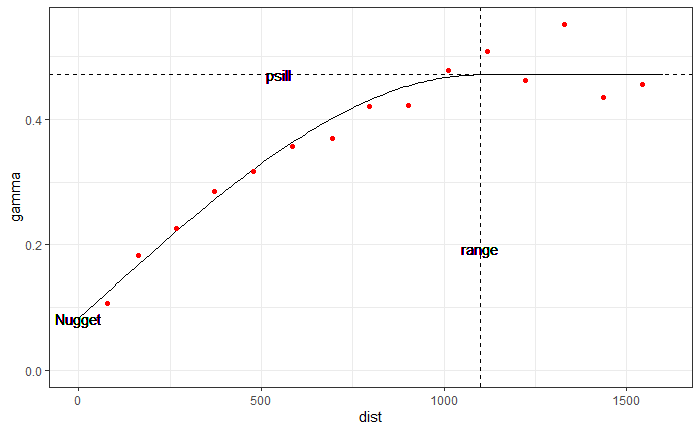

```r
ggplot(variogramLine(ajuste_var, 1600), aes(x = dist, y = gamma)) +
  geom_path() +
  geom_point(data = var_spat, color = "red") +
  geom_vline(xintercept = ajuste_var$range[2], lty = 2) +
  geom_text(x = ajuste_var$range[2], y = ajuste_var$psill[2]/2, label = "range") +
  theme_bw() +
  geom_hline(yintercept = ajuste_var$psill[2] + ajuste_var$psill[1] , lty = 2) +
  geom_text(x = ajuste_var$range[2]/2, y = ajuste_var$psill[2] + ajuste_var$psill[1], label = "psill") +
  geom_text(x = ajuste_var$range[1], y = ajuste_var$psill[1], label = "Nugget") +
  ylim(c(0,max(var_spat$gamma)))
```

# Otros modelos

```r
# Modelo nulo
ajuste_nulo <- fit.variogram(object = var_nulo,
                             model = vgm(psill = 1, model = "Sph", range =  700,
                                         nugget =  1))

# Modelo con distancia
ajuste_dist <- fit.variogram(object = var_dist,
                            model = vgm(psill = 1, model = "Sph", range =  700,
                                        nugget =  1))

# Modelo con raíz cuadrada de la distancia
ajuste_sqrt <- fit.variogram(object = var_sqrt,
                            model = vgm(psill = 1, model = "Sph", range =  700,
                                        nugget =  1))
```

- **Gráfico con cuatro modelos ajustados:**

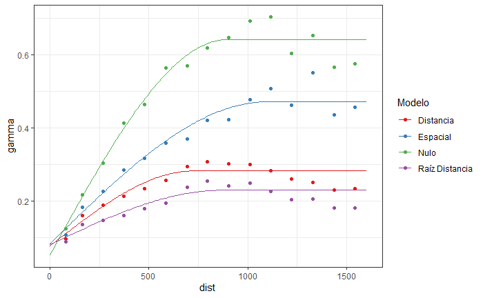

```r
# Cuatro modelos
Abn_fit_null <- variogramLine(ajuste_nulo, 1600) %>% mutate(Modelo = "Nulo")
Abn_line_Spat <- variogramLine(ajuste_var, 1600) %>% mutate(Modelo = "Espacial")
Abn_line_Dist <- variogramLine(ajuste_dist, 1600) %>% mutate(Modelo = "Distancia")
Abn_line_Dist_sq <- variogramLine(ajuste_sqrt, 1600) %>% mutate(Modelo = "Raíz Distancia")

# Unión de datos
Abn_line <- list(Abn_fit_null, Abn_line_Spat, Abn_line_Dist, Abn_line_Dist_sq) %>%
  reduce(bind_rows)

ggplot(Abn_line, aes(x = dist, y = gamma)) +
  geom_path(aes(color = Modelo)) +
  geom_point(data = all_var, aes(color = Modelo)) +
  theme_bw() +
  scale_color_brewer(palette = "Set1")
```

# Kriging

- [El krigeaje o regresión en procesos gaussianos](https://es.wikipedia.org/wiki/Krigeaje#:~:text=El%20krigeaje%2C%20krigeado%20o%20kriging,referencia%20usado%20en%20la%20estimaci%C3%B3n.) permite realizar interporlación a partir de un variograma previamente ajustado.
- En este caso se usa la base de datos *meuse.grid* que tiene información que podrá ser utilizada para la interpolación. Las distancias del siguiente gráfico indican proximidad a una fuente hídrica.

## Datos

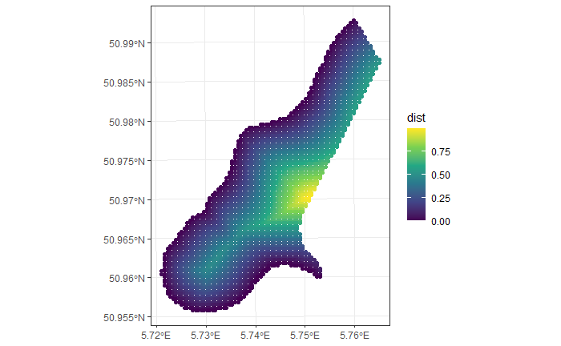

```r
# Data inicial
data("meuse.grid")

# Conversión a sf
meusegrid_sf <- meuse.grid %>%
  st_as_sf(coords = c(1, 2), crs = "+init=epsg:28992")

# Gráfico
meusegrid_sf %>%
  ggplot() +
  geom_sf(aes(color = dist)) +
  scale_color_viridis_c() +
  theme_bw()
```

## Predicciones (interpolación)

```r
pred_spat <- krige(log(zinc) ~ 1, meuse_sf, meusegrid_sf, model = ajuste_var)
```

```
[using ordinary kriging]
```

```r
class(pred_spat)
```

```
[1] "sf"         "data.frame"
```

```r
pred_spat
```

```
Simple feature collection with 3103 features and 2 fields
geometry type:  POINT
dimension:      XY
bbox:           xmin: 178460 ymin: 329620 xmax: 181540 ymax: 333740
projected CRS:  Amersfoort / RD New
First 10 features:
   var1.pred  var1.var              geometry
1   6.535255 0.2461491 POINT (181180 333740)
2   6.626923 0.2093807 POINT (181140 333700)
3   6.528438 0.2197185 POINT (181180 333700)
4   6.429889 0.2315686 POINT (181220 333700)
5   6.730607 0.1709532 POINT (181100 333660)
6   6.622317 0.1818457 POINT (181140 333660)
7   6.508323 0.1944079 POINT (181180 333660)
8   6.396911 0.2074667 POINT (181220 333660)
9   6.835826 0.1364733 POINT (181060 333620)
10  6.728034 0.1437661 POINT (181100 333620)
```

- **Gráfico de predicciones:** como los datos están en logaritmos se usa la función exp() para obtener valores en las mismas unidades

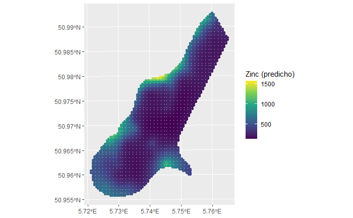

```r
pred_spat %>%
  ggplot() +
  geom_sf(aes(color = exp(var1.pred))) +
  scale_color_viridis_c(name = "Zinc (predicho)")
```

- **Gráfico de variación en las predicciones:** el gráfico permite evidencicar lugares de mayor incertidumbre para la predicción.

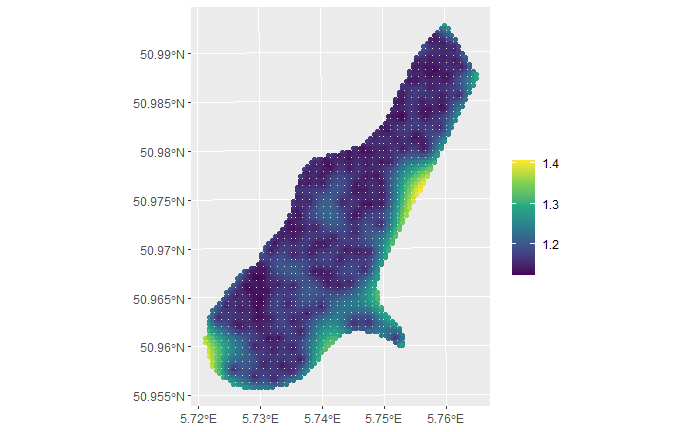

```r
pred_spat %>%
  ggplot() +
  geom_sf(aes(color = exp(var1.var))) +
  scale_color_viridis_c(name = "")
```

## Todos los modelos

```r
Null_pred <- krige(log(zinc) ~ 1,  meuse_sf, meusegrid_sf, model = ajuste_nulo) %>%
  mutate(Modelo = "Nulo")
```

```
[using ordinary kriging]
```

```r
Spat_pred <- krige(log(zinc) ~ 1, meuse_sf, meusegrid_sf, model = ajuste_var) %>%
  mutate(Modelo = "Espacial")
```

```
[using ordinary kriging]
```

```r
Dist_pred <- krige(log(zinc) ~ 1,  meuse_sf, meusegrid_sf, model = ajuste_dist) %>%
  mutate(Modelo = "Distancia")
```

```
[using ordinary kriging]
```

```r
Dist_sq_pred <- krige(log(zinc) ~ 1, meuse_sf, meusegrid_sf, model = ajuste_sqrt)  %>%
  mutate(Modelo = "Raíz Distancia")
```

```
[using ordinary kriging]
```

```r
Pred <- list(Null_pred, Spat_pred, Dist_pred, Dist_sq_pred) %>%
  reduce(bind_rows)
Pred
```

```
Simple feature collection with 12412 features and 3 fields
geometry type:  POINT
dimension:      XY
bbox:           xmin: 178460 ymin: 329620 xmax: 181540 ymax: 333740
projected CRS:  Amersfoort / RD New
First 10 features:
   var1.pred  var1.var Modelo              geometry
1   6.499611 0.3198081   Nulo POINT (181180 333740)
2   6.622347 0.2520183   Nulo POINT (181140 333700)
3   6.505156 0.2729842   Nulo POINT (181180 333700)
4   6.387580 0.2955285   Nulo POINT (181220 333700)
5   6.764490 0.1779374   Nulo POINT (181100 333660)
6   6.635508 0.2022009   Nulo POINT (181140 333660)
7   6.497544 0.2277371   Nulo POINT (181180 333660)
8   6.361471 0.2524902   Nulo POINT (181220 333660)
9   6.904628 0.1099817   Nulo POINT (181060 333620)
10  6.780233 0.1280782   Nulo POINT (181100 333620)
```

- **Predicciones:**

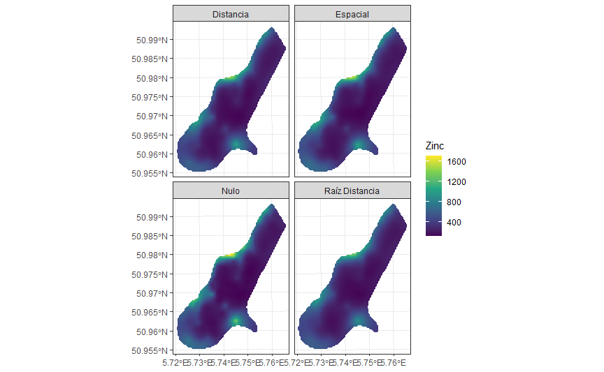

```r
ggplot() +
  geom_sf(data = Pred, aes(color = exp(var1.pred))) +
  scale_color_viridis_c(name = "Zinc") +
  facet_wrap(~Modelo)  +
  theme_bw()
```

- **Incertidumbre en predicciones:** el modelo de mayor incertidumbre es el modelo nulo.

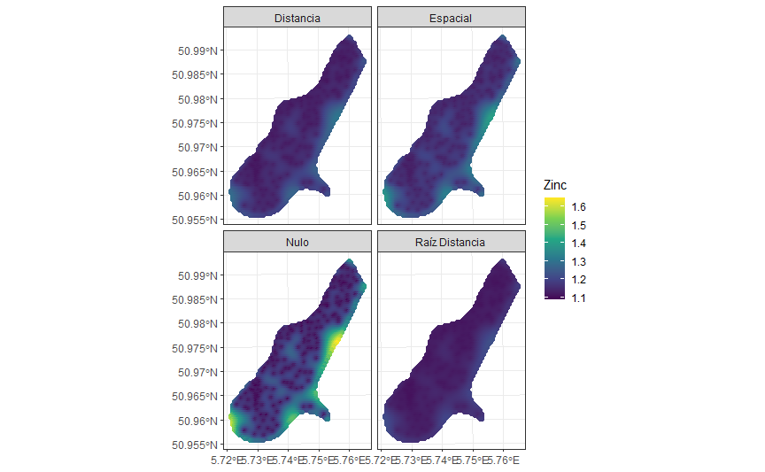

```r
ggplot() +
  geom_sf(data = Pred, aes(color = exp(var1.var))) +
  scale_color_viridis_c(name = "Zinc") +
  facet_wrap(~Modelo)  +
  theme_bw()
```

# Mejor modelo

- Una manera de seleccionar el modelo podría ser comparar la bondad de ajuste a través de una métrica que represente el error, por ejemplo, Raíz del Cuadrado Medio del Error (RSME - Root Square Mean Error).
- También es posible implementar validación cruzada.
- La función krige.cv permite ajustar modelos a través de validación cruzada.

```r
Null_pred_cv <- krige.cv(log(zinc) ~ 1,  meuse_sf,
                         model = ajuste_nulo, nfold = 5) %>%
  mutate(Modelo = "Nulo")

Spat_pred_cv <- krige.cv(log(zinc) ~ 1, meuse_sf,model = ajuste_var,
                         nfold = 5) %>%
  mutate(Modelo = "Espacial")

Dist_pred_cv <- krige.cv(log(zinc) ~ 1,  meuse_sf, model = ajuste_dist,
                         nfold = 5) %>%
  mutate(Modelo = "Distancia")

Dist_sq_pred_cv <- krige.cv(log(zinc) ~ 1, meuse_sf, model = ajuste_sqrt,
                         nfold = 5)  %>%
  mutate(Modelo = "Raíz Distancia")

Pred_cv <- list(Null_pred_cv, Spat_pred_cv, Dist_pred_cv, Dist_sq_pred_cv) %>%
  reduce(bind_rows)
```

- **Predichos vs observados:**

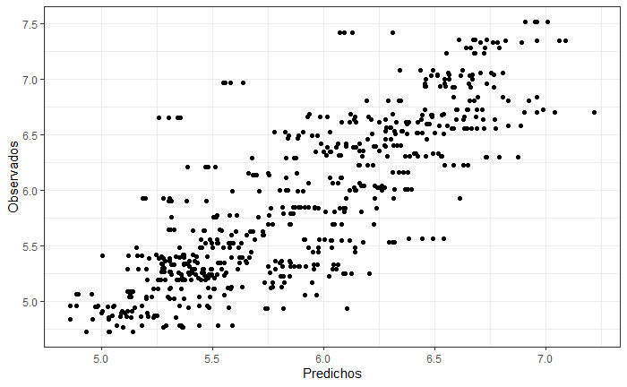

```r
Pred_cv %>%
  ggplot(aes(x = var1.pred, y = observed)) +
  geom_point() +
  theme_bw() +
  labs(x = "Predichos", y = "Observados")
```

- **Comparando modelos a través de RMSE:**

```r
Pred_cv %>%
  as.data.frame() %>%
  group_by(Modelo) %>%
  summarise(RMSE = sqrt(sum(residual^2)/length(residual)))
```

| Modelo | RMSE |
| --- | --- |
| Distancia | 0.4291398 |
| Espacial | 0.4070788 |
| Nulo | 0.3925986 |
| Raíz Distancia | 0.4352926 |